# Single Bivalent Level Analysis

April Peterson

23 January 2020

# Setup and Discription of Dataset

This plot illustrates how well the algorithm seperated indiviual bivalents per cell image. Several MSM male spreads had tight cells with a high degree of overlap, so fewer bivalents were indiviudally segmented.

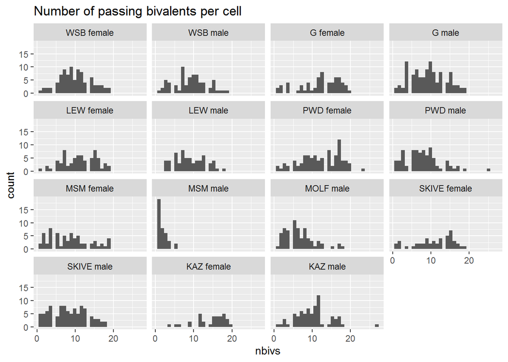

consider making a table with predictions for bivalent patterns which are related to the mechanism

# Chrm Class proportions

Should I be thinking of making a MM or lm for predicting CO number (within a category)

but there is so little variance in the CO number

co ~ sc.length

I ran this model before, I remember that these models are better predictors (more significant for males than females)

maybe – female nuanced pattern – falls along the lines of

simple predictions not met as strongly as in male patterns…

this reasoning might be complicated by the fact that the range in CO averages is lower in females – so there is less power

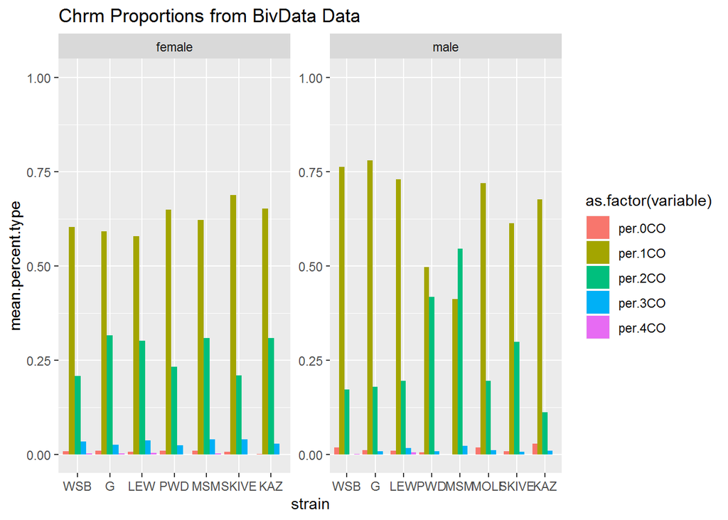

the above plot displays the average proportion of each type of chromosome class across mice. The results mostly align with the hand measured results.

Look into ordering the mouse strains to highlight the MSM and PWD differences, renameing the chrm type labels, spacing out the x axis labels or removing some of the other mice.

# Chromosome Size effect

In an attempt to deal with the chromosome effect size that is know to effect total rate and CO position, we try to make a dataset of the longest 25% SC from a cell.

The majority of cells from the BivData set do not have the complete completement of bivalents, (ie they are missing up to 5) – which makes it hard to use a absolute length threshold since some cells have shorter or longer bivalents compared to the while. So an absolute measure might catch the lower 25% of some cells.

I’d like to figure out how to best seperate out the true 4th quartille bivalents (longest 25%), even with this missing data. double check that 4th quartille is top 5/4

Could I use the total SC? (I would be warry: can’t ensure that they apply the same skeletonize algorithm/parameters and the XY is also included in that count and will mess everything up.)

outline logic for filtering / choosing BivData set of almost whole cells

- 16 to 20 bivalents in the cells

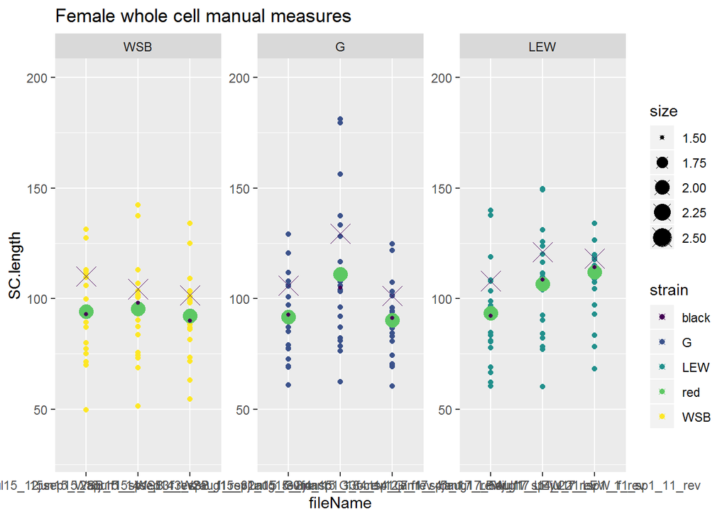

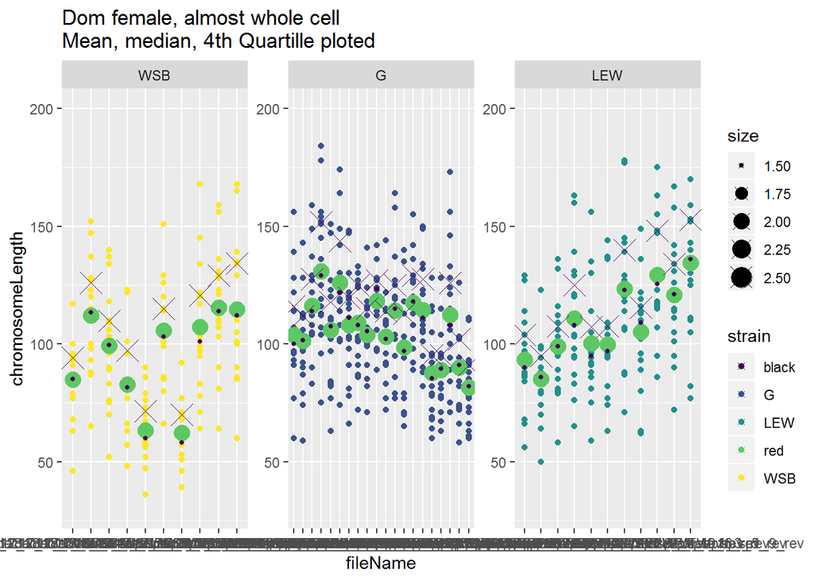

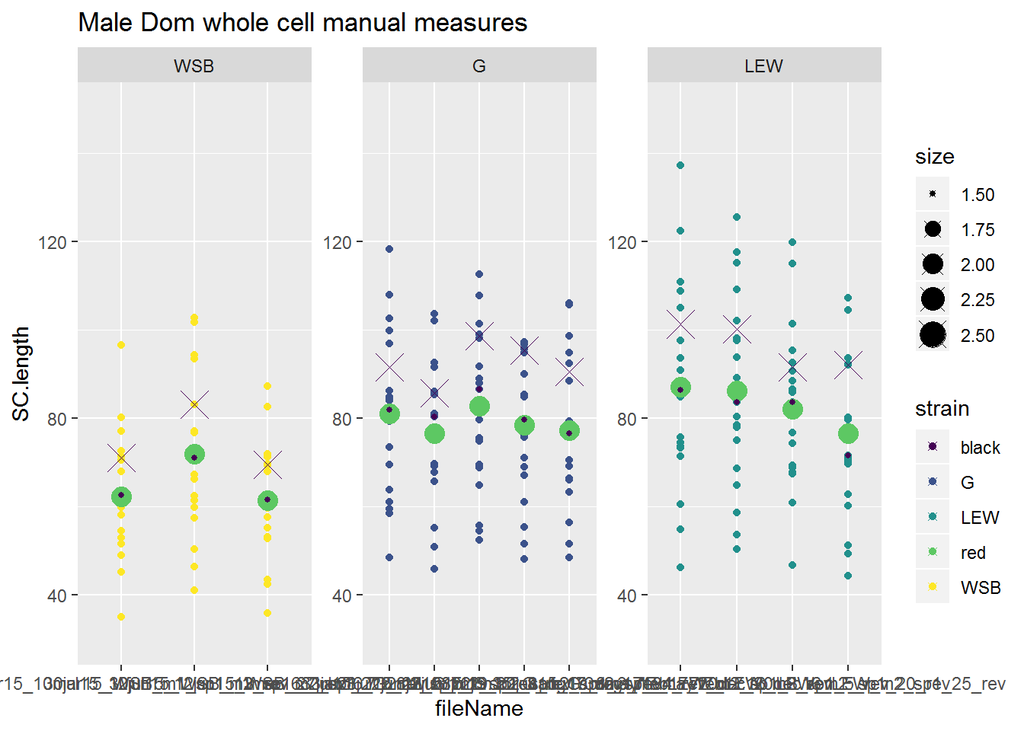

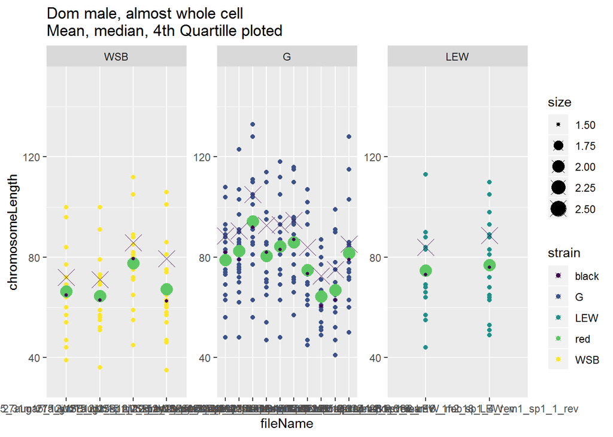

I’m purposing to take all the automated biv measures above the cell’s 4th quartille as a dataset for ‘longestest’ bivalents which we would predict to exclude the shortest chromsomes which would have stronger chromsome size effects.

But this dataset might be noisy, given the amount of variance in the SC length distributions across cells (PWD females, WSB females). But it’s easier to just run another set of analysis.

Biv_Data_mean_table has the Q4 values

```
## [1] 2605
```

```
## [1] 1997
```

[output not shown]

[output cut: 226 more lines]

```
##                                     5
##      9aug15_17apr15_PWD_f2_sp1_21_rev
##                                     4
##     9aug15_17apr15_PWD_f2_sp1_3.2_rev
##                                     5
##      9aug15_23apr15_PWD_f2_sp1_11_rev
##                                     5
##       9aug15_23apr15_PWD_f2_sp1_6_rev
##                                     4
##       9aug15_23apr15_PWD_f2_sp1_8_rev
##                                     5
##         9mar16_22feb16_G_m1_sp1_6_rev
##                                     5
##         9mar16_22feb16_G_m1_sp1_8_rev
##                                     4
```

Well fixing those bigs took forever

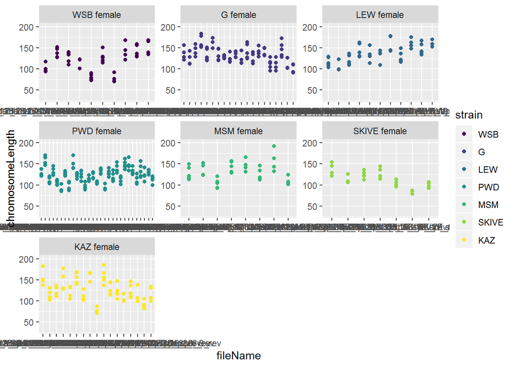

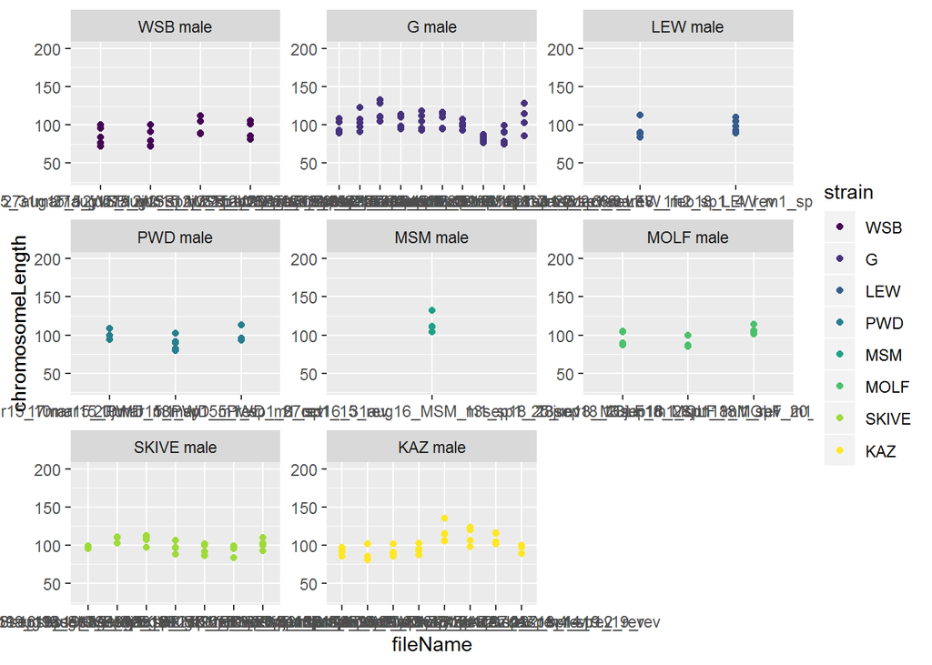

These plots show the SC lengths for bivalents I’m calling the ‘long SC data set’. They are supposed to be the longest 4-5 SC from cells where I could get good measures. These longer bivalents are useful because their patterns shouldn’t be affect by chromsome size effect (which effects, CO position). Hopefully this data set will have less noise from chromosome identity, but there was still data missing (they don’t come from whole cell measures).

# Applying Mix Model framework

I will use two different mixed models using lme() and lmer(), because the different models have limitations for reporting p values ect.

list out pros and cons for using mouse averages of bivalent traits instead of using the single bivalent traits them selves.

**Pro Bivalent level**

- The data are continous and closer to normal/gaussian expectations than the MLH1 counts.
- There is within cell variance that is an issue.

**Pro Mouse level averages**

- Mouse average is a conserved framework, it would summarize general patterns which fits with the paper.
- Simple application of the same MM.
- Limited work to add to the dataset if I can justify that the collection of single bivalents are random and equivilent across mice.

## Predictions, Heterochiasmy

Using the Mixed model framework which tests the effects (and interactions) of subspecies, sex and strain, I will test for evolution of the following traits.

Two bivalent level traits are predicted to display heterochiasmy (ie significant effects of sex);

1. SC length (cite Lynn)

2.A) normalized CO positions (sedell and Kirkpatrick).

2. **sis**ter **co**hesion **ten**sion (sis-co-ten) will be sexually dimorphic as it reflects the general property of unifrom vs telomere/biased CO positioning.
3. Interference, measured in the physical units, has been shown to lack sexual dimorphism (petkov).

These 3 hypotheses will be tested with the mixed model framework, specifically focusing on the effect of sex.

Mouse averages for the each metric will be used.

## Predictions, male polymorphism

What predictions do I have for how traits will differ between the low and high Musc mouse strains?

1. **SC lengths** will be longer for high Rec

B.1) **Interfernce/IFD** will be shorter in high Rec

or

B.2) **Interference/IFD** will be longer in high Rec males, sis-co-ten metric will be maximized. (given prelim results from Beth’s data)

Using the same MM framework we would expect the random strain effect would be significant for these predictions.

Use just the male (Musc male data)

$$mouse \ average \ SC \ length ~=~ rand(strain) + \varepsilon$$

$$mouse \ average \ IFD \ trait ~=~ rand(strain) + \varepsilon$$
The IFD traits are:

- IFD_ABS
- IFD_PER

$$mouse \ average \ CO \ position \ trait ~=~ rand(strain) + \varepsilon$$

The CO position traits are:

- 1CO position
- centromere and telomere distance
- sis-co-ten

# SC Lengths

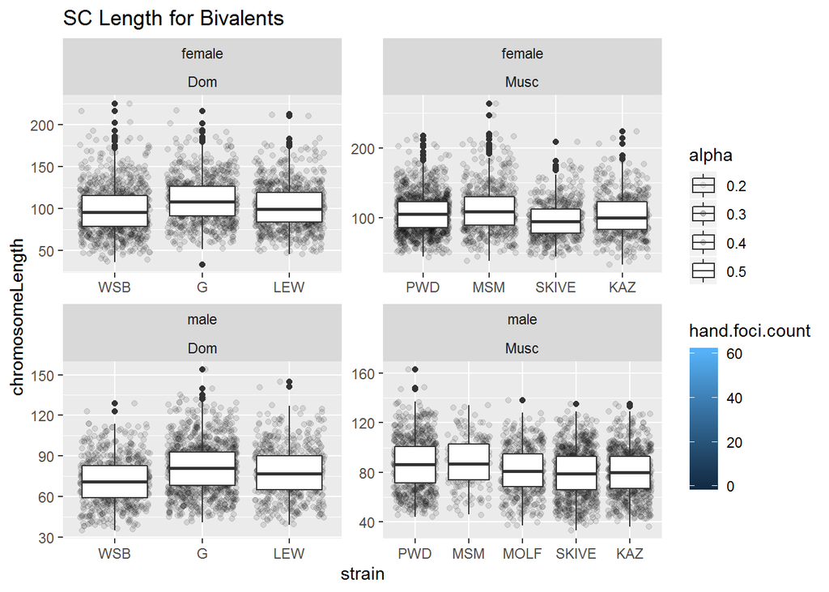

TRY ADDING NESTED boxplots for hand.foci.count

$$mouse \ average \ SC \ length ~=~ subsp * sex + rand(strain*sex) + \varepsilon$$

To estimate random effects, I’m using lmer (not lme where I could do the rand(strain*sex)). So now it’s just random(strain).

Above is the model we are testing evolution of SC lengths. remember for the MM use the table **mouse.avs_4MM**

|  | Value | Std.Error | DF | t-value | p-value |
| --- | --- | --- | --- | --- | --- |
| (Intercept) | 105.881501 | 2.969417 | 76 | 35.657340 | 0.000000 |
| subspMusc | 0.364038 | 3.895152 | 6 | 0.093459 | 0.928581 |
| sexmale | -28.769236 | 2.566342 | 76 | -11.210210 | 0.000000 |
| subspMusc:sexmale | 6.037493 | 3.499145 | 76 | 1.725420 | 0.088516 |

I used the mixed model with the lme()

$$mouse \ average \ SC \ length ~=~ subsp * sex + rand(strain) + \varepsilon$$

|  | Df | Sum Sq | Mean Sq | F value |
| --- | --- | --- | --- | --- |
| subsp | 1 | 38.3005 | 38.3005 | 0.6367611 |
| sex | 1 | 12873.1353 | 12873.1353 | 214.0210313 |
| subsp:sex | 1 | 179.0678 | 179.0678 | 2.9770734 |

```
##
##  simulated finite sample distribution of RLRT.
##
##  (p-value based on 10000 simulated values)
##
## data:
## RLRT = 6.6745, p-value = 0.0028
```

### Heterochiasmy Prediction

> Is sex a significant effect for SC length? (as predicted)
- Sex is a significant effect for SC length The results seem to indicate that sex is a significant factor. Consider writing a subsampling approach (randomize / permute a data set of BivData)
- According to anova, sex effect explains most of the variance in single bivalent SC lengths.

> Is the random Effect of strain an effect on SC length?

The exactRLRT() test indicates that the random strain effect might be significant, p= 0.0028.

### Male polymorphism Predcition

Preidction, High rec males have longer SC.

I can’t get the above mixed models to work for testing high vs low rec groups

> Is the prediction, high rec musc male strains have long SC met?

# IFD

**I**nter**f**ocal **D**istance, a indication of CO interference.

How can I highlight the result (I need to verify this first) for greater IFD in high rec male mice?

The raw measures are pretty nosy, this might not be the best way to display these results.

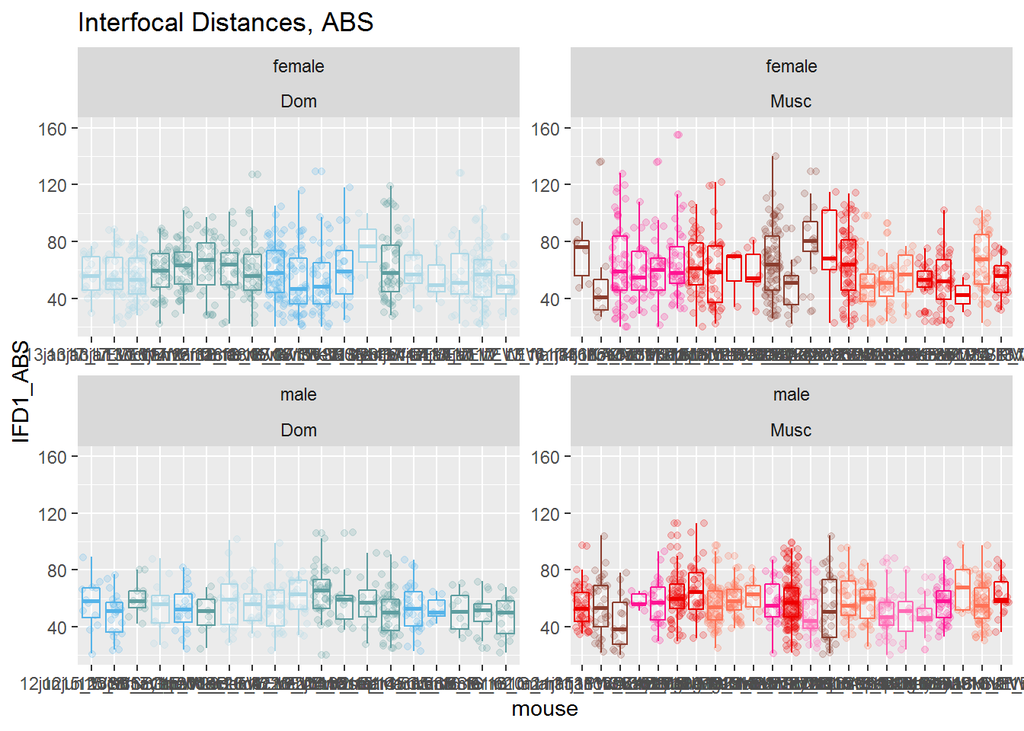

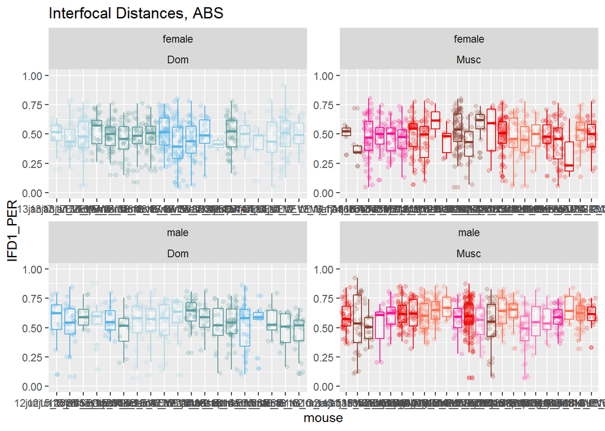

Above is the first plots of IFDs. Each point is a IFD observation. colors are by mouse. Maybe add mouse level lines for the means

Maybe I should try binned the SC lengths.

mixed model analysis for IFD (interference), the first set of models are made with the lme() functions.

$$mouse \ average \ IFD ~=~ subsp * sex + rand(strain*sex) + \varepsilon$$

|  | Value | Std.Error | DF | t-value | p-value |
| --- | --- | --- | --- | --- | --- |
| (Intercept) | 56.883432 | 1.767019 | 74 | 32.191747 | 0.000000 |
| subspMusc | 0.537733 | 2.387822 | 6 | 0.225198 | 0.829299 |
| sexmale | -6.553238 | 3.140639 | 74 | -2.086594 | 0.040370 |
| subspMusc:sexmale | 3.902914 | 4.148173 | 74 | 0.940875 | 0.349830 |

|  | Value | Std.Error | DF | t-value | p-value |
| --- | --- | --- | --- | --- | --- |
| (Intercept) | 0.472243 | 0.010231 | 74 | 46.157364 | 0.000000 |
| subspMusc | 0.005346 | 0.013826 | 6 | 0.386663 | 0.712347 |
| sexmale | 0.071002 | 0.025648 | 74 | 2.768366 | 0.007115 |
| subspMusc:sexmale | 0.028528 | 0.033182 | 74 | 0.859722 | 0.392719 |

### second set of Mixed Models

These seond set of models are made using the lmer()

$$mouse \ average \ IFD ~=~ subsp * sex + rand(strain) + \varepsilon$$

$$mouse \ average \ normalized IFD ~=~ subsp * sex + rand(strain) + \varepsilon$$

I tested 2 versions of the mixed model for this flavor of trait, raw IFD and normalized IFD measure. The tables below are from anova( for the lmer model )

```
## boundary (singular) fit: see ?isSingular
```

|  | Df | Sum Sq | Mean Sq | F value |
| --- | --- | --- | --- | --- |
| subsp | 1 | 155.4065 | 155.4065 | 2.464508 |
| sex | 1 | 346.8584 | 346.8584 | 5.500643 |
| subsp:sex | 1 | 100.2644 | 100.2644 | 1.590040 |

```
## boundary (singular) fit: see ?isSingular
```

|  | Df | AIC | LRT | Pr(Chi) |
| --- | --- | --- | --- | --- |
|  | NA | 594.3836 | NA | NA |
| subsp:sex | 1 | 594.0368 | 1.653167 | 0.1985285 |

```
##
##  simulated finite sample distribution of RLRT.
##
##  (p-value based on 10000 simulated values)
##
## data:
## RLRT = 0, p-value = 1
```

|  | Df | Sum Sq | Mean Sq | F value |
| --- | --- | --- | --- | --- |
| subsp | 1 | 0.004450460 | 0.004450460 | 1.972135 |
| sex | 1 | 0.164462573 | 0.164462573 | 72.878392 |
| subsp:sex | 1 | 0.007950068 | 0.007950068 | 3.522918 |

|  | Df | AIC | LRT | Pr(Chi) |
| --- | --- | --- | --- | --- |
|  | NA | -258.4535 | NA | NA |
| subsp:sex | 1 | -256.9996 | 3.453883 | 0.06310335 |

```
##
##  simulated finite sample distribution of RLRT.
##
##  (p-value based on 10000 simulated values)
##
## data:
## RLRT = 1.9997, p-value = 0.0571
```

```r
#make
```

### Heterochiasmy Prediction

> Do the IFD measures lack significant sex effect? (as predicted)

There are sex effects for the lme() models for both the ABS and PER IFD measures. There is slight evidence for significant strain effect.

> Are there signiticant strain effects?

The random strain effect was tested for raw and normalized IFD, neither are signifcant.

### Male Polymorphism Prediction

> prediction A, Is the Male polymorphism Prediction met? High rec strains have shorter IFDs?

```
##
## Call:
## glm(formula = Rec.group ~ mean_IFD.2CO_ABS, family = binomial(link = "logit"),
##     data = mouse.avs_4MM_M.male)
##
## Deviance Residuals:
##     Min       1Q   Median       3Q      Max
## -1.5101  -0.9963  -0.7545   1.2282   1.7485
##
## Coefficients:
##                  Estimate Std. Error z value Pr(>|z|)
## (Intercept)      -5.64222    4.13508  -1.364    0.172
## mean_IFD.2CO_ABS  0.09329    0.07326   1.273    0.203
##
## (Dispersion parameter for binomial family taken to be 1)
##
##     Null deviance: 30.789  on 22  degrees of freedom
## Residual deviance: 29.006  on 21  degrees of freedom
## AIC: 33.006
##
## Number of Fisher Scoring iterations: 4
```

```
##
## Call:
## glm(formula = Rec.group ~ mean_IFD.2CO_PER, family = binomial(link = "logit"),
##     data = mouse.avs_4MM_M.male)
##
## Deviance Residuals:
##     Min       1Q   Median       3Q      Max
## -1.1070  -1.0202  -0.9232   1.3397   1.4669
##
## Coefficients:
##                  Estimate Std. Error z value Pr(>|z|)
## (Intercept)        -2.141      4.774  -0.448    0.654
## mean_IFD.2CO_PER    2.891      8.080   0.358    0.720
##
## (Dispersion parameter for binomial family taken to be 1)
##
##     Null deviance: 30.789  on 22  degrees of freedom
## Residual deviance: 30.660  on 21  degrees of freedom
## AIC: 34.66
##
## Number of Fisher Scoring iterations: 4
```

None of the logistic regression models for ABS or PER IFD lengths are sigificant, even when just the Musc strains are used.

Post-hoc comparisons ideas?

Preliminary results from an independant dataset indecated that PWD had longer IFDs, which goes agaisnt the simple prediction of more COs ~ denser spacing of foci on the same bivalent. This also indecated that interference distance may evolved in the house mouse complex.

> Prediction B, Is there evidence for the alternative IFD meansure

# General CO Positions

There are a few traits that fall within the CO positions

- 1CO normalized position
- sis.co.ten (sorta interference)
- centromere and telomere distance

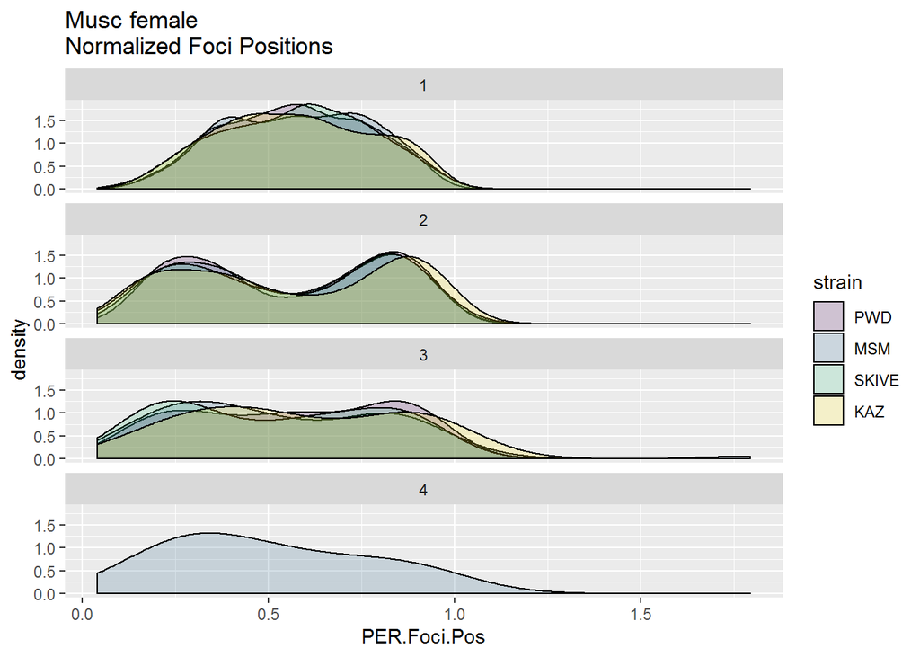

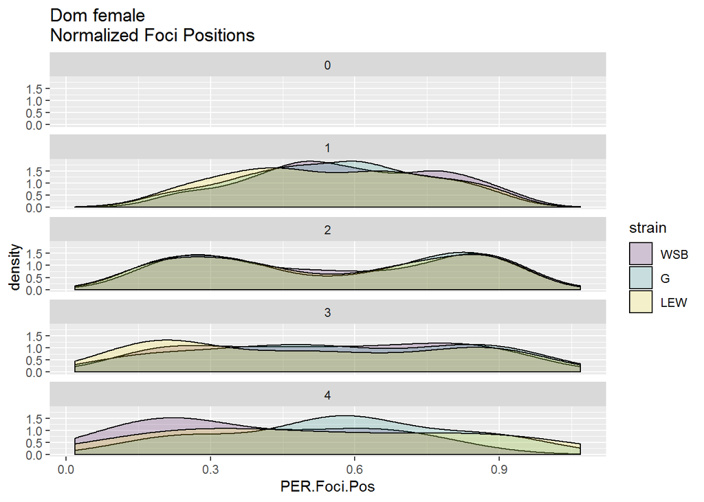

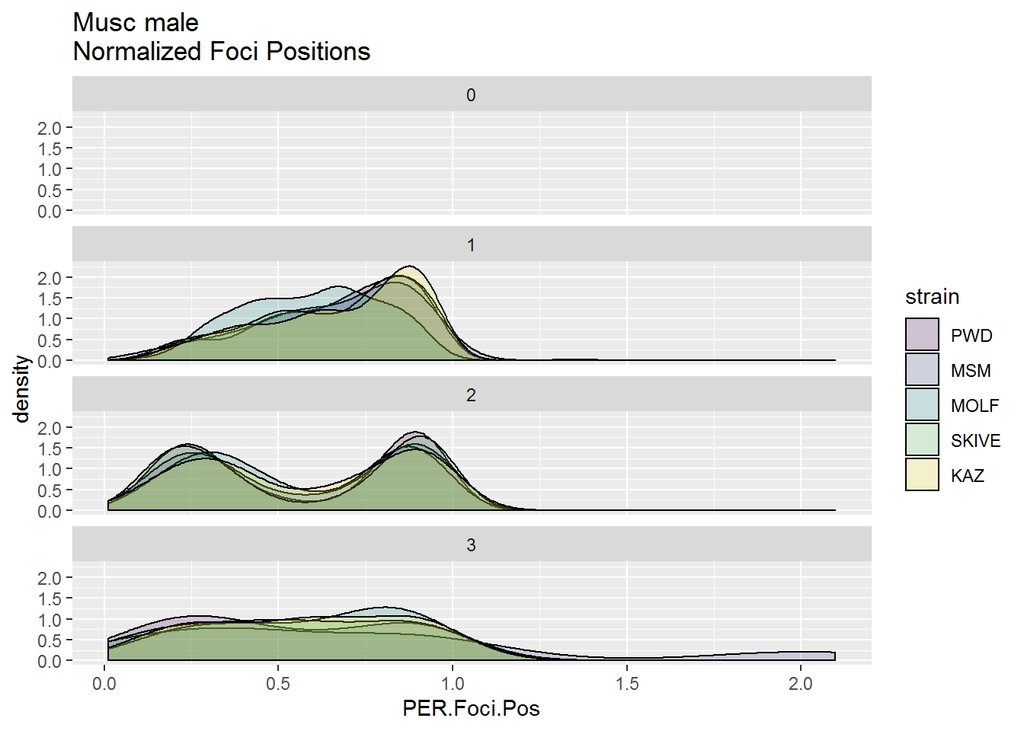

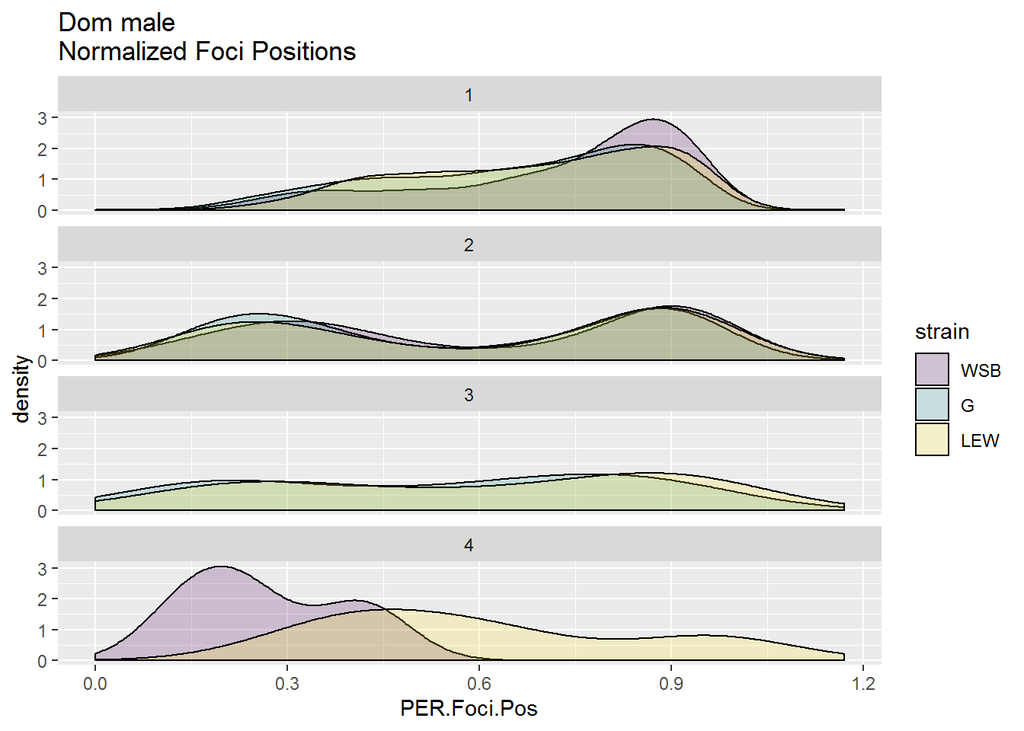

Split up the plot data by subsp - sex. Try adding in the numbers of observations? think about adding a vertical line for centromere, for the position means. Think about removing the extra Musc strains.

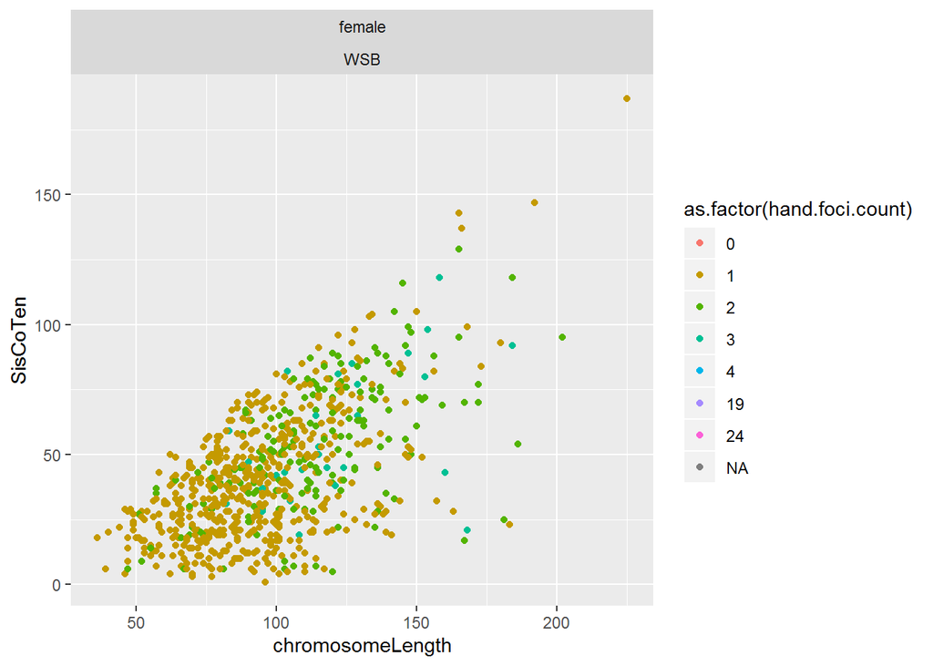

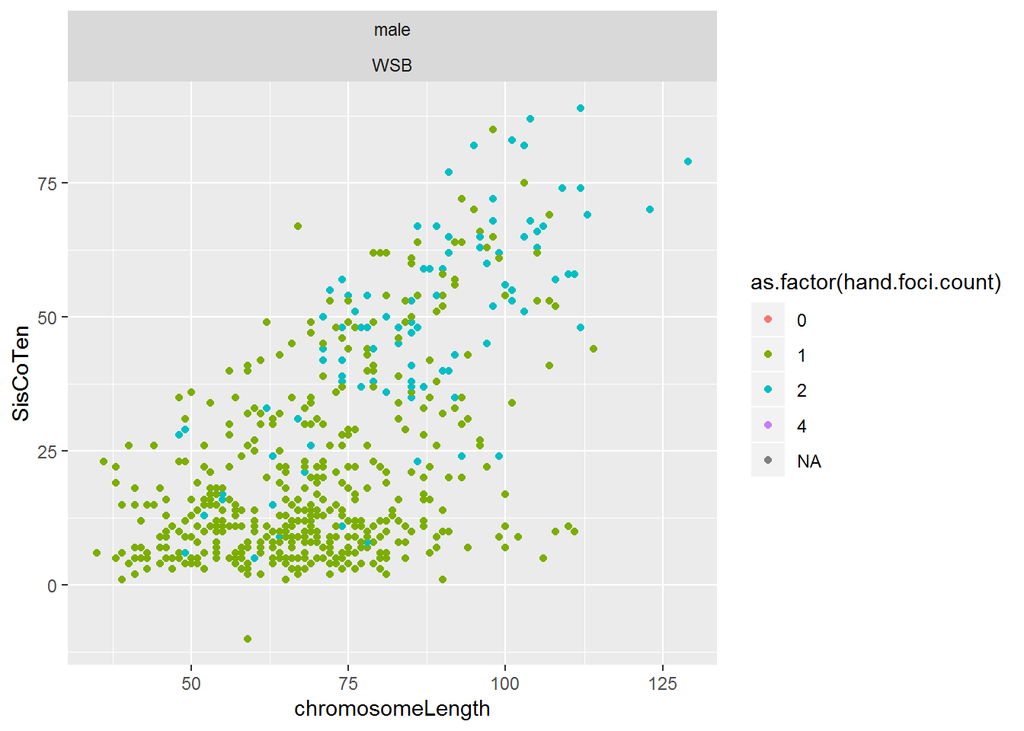

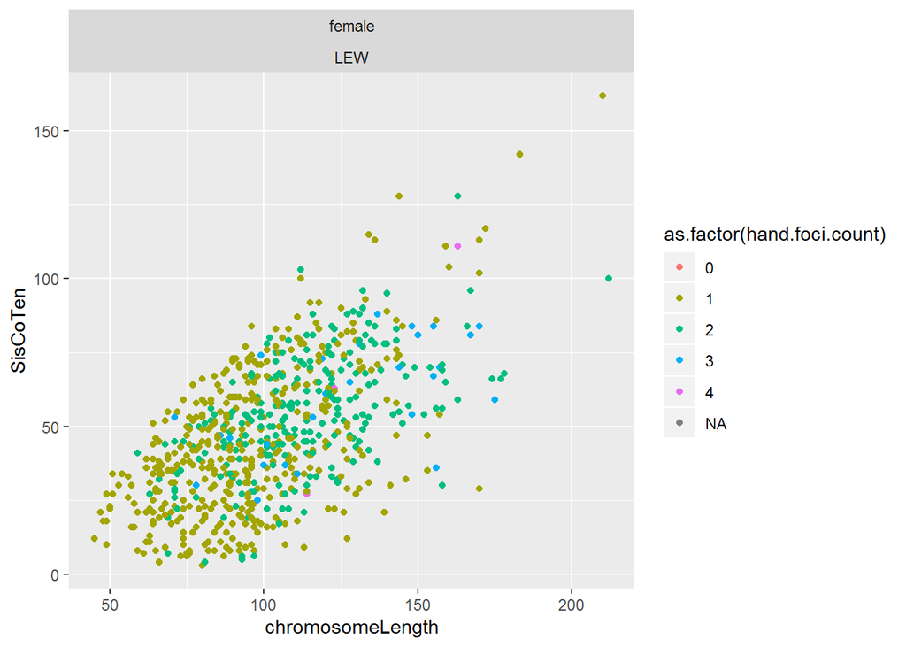

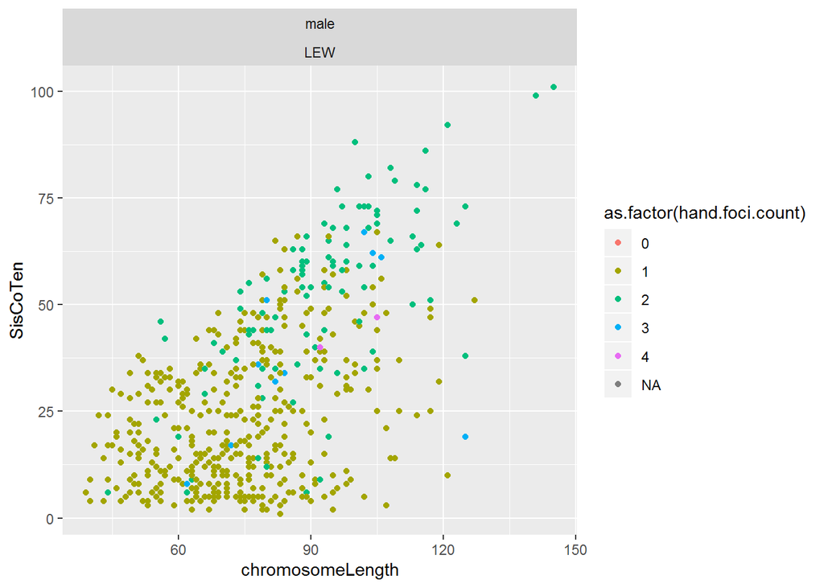

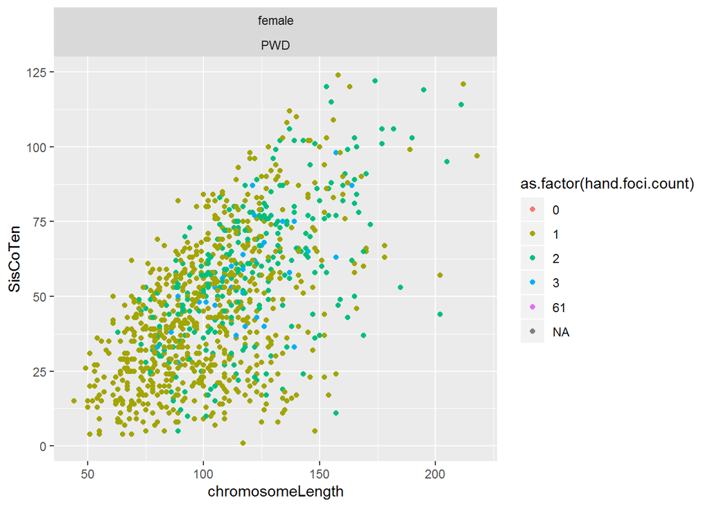

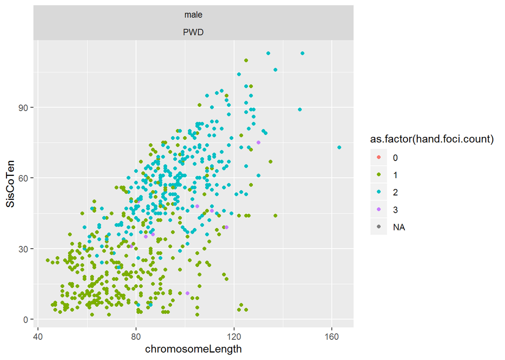

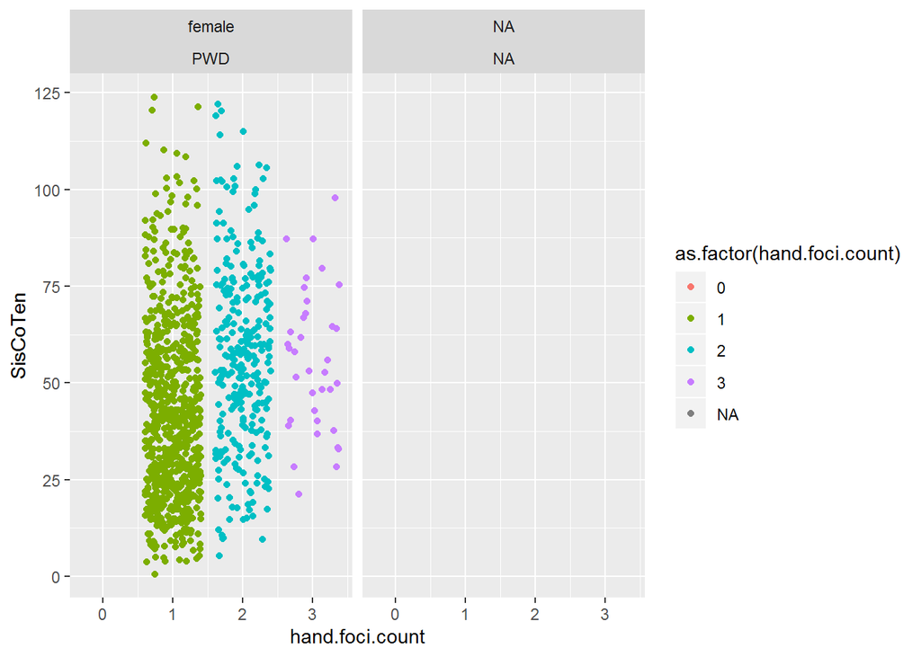

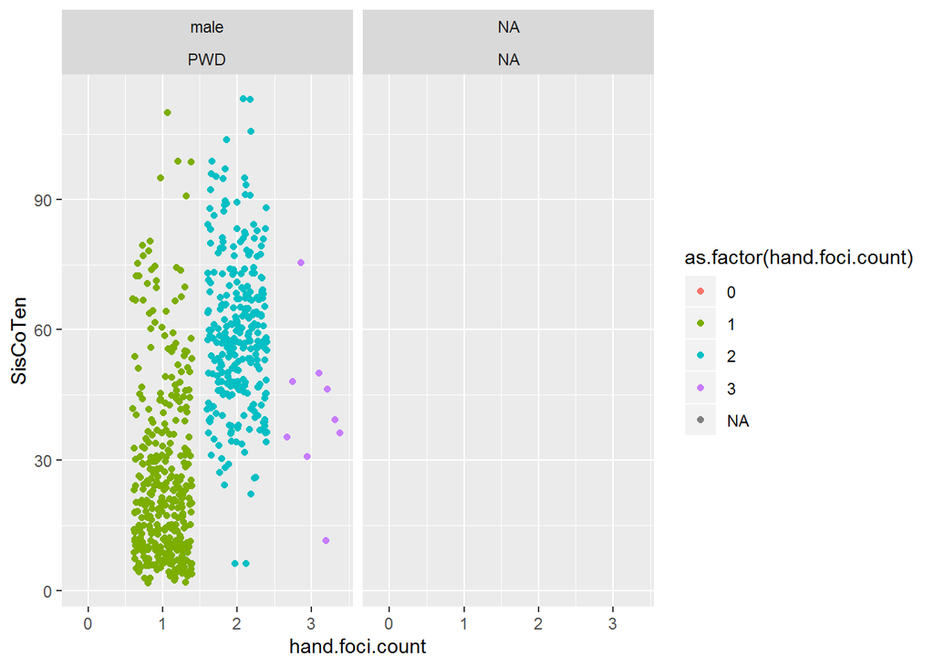

the distribution of SC lengths and sis-coten seems very different across sexes

$$mouse \ average \ F1 position ~=~ subsp * sex + rand(strain) + \varepsilon$$

The mixed model data should only come from 1CO bivalent data.

|  | Df | Sum Sq | Mean Sq | F value |
| --- | --- | --- | --- | --- |
| subsp | 1 | 0.0006200136 | 0.0006200136 | 0.5939016 |
| sex | 1 | 0.2693721320 | 0.2693721320 | 258.0274435 |
| subsp:sex | 1 | 0.0039003751 | 0.0039003751 | 3.7361096 |

```
## Linear mixed model fit by REML ['lmerMod']
## Formula: norm.first.foci.pos ~ subsp * sex + (1 | strain)
##    Data: mouse.avs_4MM
##
## REML criterion at convergence: -288.6
##
## Scaled residuals:
##     Min      1Q  Median      3Q     Max
## -3.6500 -0.6255 -0.0452  0.5151  3.2887
##
## Random effects:
##  Groups   Name        Variance  Std.Dev.
##  strain   (Intercept) 0.0009902 0.03147
##  Residual             0.0010440 0.03231
## Number of obs: 82, groups:  strain, 8
##
## Fixed effects:
##                    Estimate Std. Error t value
## (Intercept)        0.559971   0.019834  28.232
## subspMusc         -0.005967   0.025507  -0.234
## sexmale            0.135770   0.010934  12.417
## subspMusc:sexmale -0.029024   0.015016  -1.933
##
## Correlation of Fixed Effects:
##             (Intr) sbspMs sexmal
## subspMusc   -0.778
## sexmale     -0.290  0.225
## sbspMsc:sxm  0.211 -0.316 -0.728
```

```
##
##  simulated finite sample distribution of RLRT.
##
##  (p-value based on 10000 simulated values)
##
## data:
## RLRT = 14.982, p-value = 1e-04
```

### Heterochiasmy Prediction

> Is sex a significant effect for the 1CO normalized CO position? (as predicted)

> is random strtain effect significant?

The random strain effect seems very significant.

remember to use the mouse average table **mouse.avs_4MM** (I don’t think I need the MELT data frame)

```r
#make point plots / boxplots which show differences in mean positions

#scatter + boxplot for t.tests
```

Dr. Broman suggested that the Smirnov K /(curve comparison) wasn’t the best test to differences in general CO position. He sugggested doing simple t-test for the positions

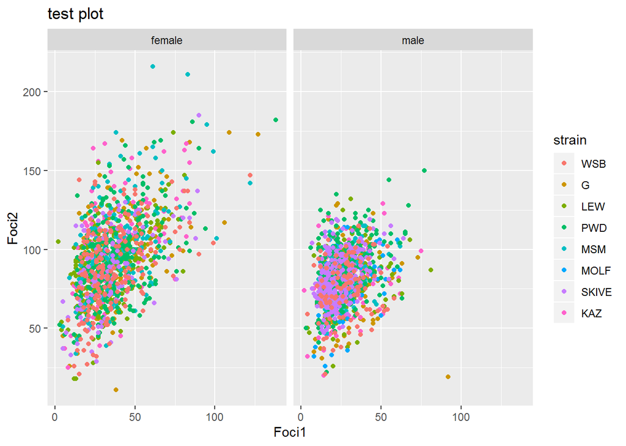

```r
#try remaking the plot Megan suggested
# for 2CO positions, Foci1, Position  on x and Foci 2 position on y

CurBivData_2CO <- Curated_BivData[Curated_BivData$hand.foci.count == 2,]

CurBivData_2CO <- CurBivData_2CO[!(is.na(CurBivData_2CO$Foci2) | CurBivData_2CO$Foci2==""), ]

#isolate 2COs
#facet by sex and subsp

F1.x.F2 <- ggplot(CurBivData_2CO, aes(x=Foci1,y=Foci2, color=strain) ) + geom_point()+ facet_wrap(~sex)+ggtitle("test plot")
F1.x.F2
```

```r
#what is the pattern of variance
#run analyses for each subsp*sex
#use non-melt DF

#how is the variance partioned across
#cell, mouse, strain

female.Dom <- Curated_BivData[Curated_BivData$sex == "female",]
female.Dom <- female.Dom[female.Dom$subsp == "Dom",]

female.Dom$Foc1.PER <- female.Dom$Foci1 / female.Dom$chromosomeLength

#unorder strain and mouse

female.Dom$mouse <- as.factor(female.Dom$mouse)


female.Dom$strain <- unclass(female.Dom$strain)
female.Dom$strain <- as.factor(female.Dom$strain)

female.Dom_1CO <- female.Dom[female.Dom$hand.foci.count == 1,]
female.Dom_1CO <- female.Dom_1CO[(!is.na(female.Dom_1CO$hand.foci.count)),]

#1CO first
modo <- lm(Foc1.PER ~ fileName + mouse + strain, data=female.Dom_1CO)

#can't get mouse and strain to have sum of square
#residual size decreases with per.F1
#residuals much larger than fileName, mouse and strain no

#model <- lm(breaks ~ wool * tension,
#            data = warpbreaks,
#            contrasts = list(wool = "contr.sum", tension = "contr.poly"))

male.Dom <- Curated_BivData[Curated_BivData$sex == "male",]
male.Dom <- male.Dom[male.Dom$subsp == "Dom",]

male.Dom$mouse <- as.factor(male.Dom$mouse)

male.Dom$strain <- unclass(male.Dom$strain)
male.Dom$strain <- as.factor(male.Dom$strain)

male.Dom <- male.Dom[male.Dom$hand.foci.count == 1,]
male.Dom <- male.Dom[(!is.na(male.Dom$hand.foci.count)),]

male.Dom$Foc1.PER <- male.Dom$Foci1 / male.Dom$chromosomeLength



male.modo <- lm(Foc1.PER ~  fileName | mouse | strain, data=male.Dom)
summary(aov(male.modo))

#only file name is registering as effect
#Review ANOVA frameworks
#http://www.biostathandbook.com/nestedanova.html
```

[output not shown]

### Male Polymorphism Prediction

I didn’t have a good prediction for the male polymorphism… So I’ll just do post-hoc comparisons for the groups to test if they are different.

```r
#I
#CO_pos
```

# old drafts

I went on a kick thinking of the sis-coten metric, I’m not so sure this is a good metric anymore. Do paired t-tests for all the male strains; test is foci position distributions are different.

1CO(F1) 1CO(F1)

2CO(F1) vs 2CO(F1) 2CO(F2) vs 2CO(F2)

Predictions for sis-coten stabilizing selection

Because it enables tighter regulation of the spindle assembly checkpoint (SAC) the centrosomic metaphase spindle in male gametogenesis can impose selection on relative CO placement (broad scale REC landscape). (OR generally due to the stronger sensitivity of the SAC in sperm/males). Following certain assumptions, the axis length and relative positions of COs can change the amount sister-cohesin over which tension is generated on the metaphase I spindle. This can be thought of as the bivalent structure when they are in the process of bipolar orientation.

under strong purifying selection, (the idea is that bivalent structures evolve to efficienctly pass the SAC) (there might be mulitple ways to do this)

- similar amount of sister cohesion tension -related to the rate of sister cohesion degregation. So all bivalents seperate at a similar rate (enter anaphase and complete anaphase in a synchronized manner).
- tension for SAC detection
1. In MSM and PWD males (the high recombining strains), 1COs should have less of a telomere bias compared to the other low rec mice (IFD).

The MSM and PWD males have approximately 50% 1CO, 50% 2CO compared to lower recombining strains (Dom and musc) 75% 1CO, 25% 2CO.

If the metaphase spindle / SAC evolved a new optimal amount of sister cohesion for the spindle tension to be spread over, the parameters of relative co placement and CO interference can evolve so that they are similar across .

2. Sister cohesin tension area for 1COs should trend more similar to 2COs in high recombining strains.

what’s the rational for this prediction?

# 3. Lack of strain specific patterns in females

the vls are much closer in females

# SC length traits

Females have higher variance in more meiotic traits

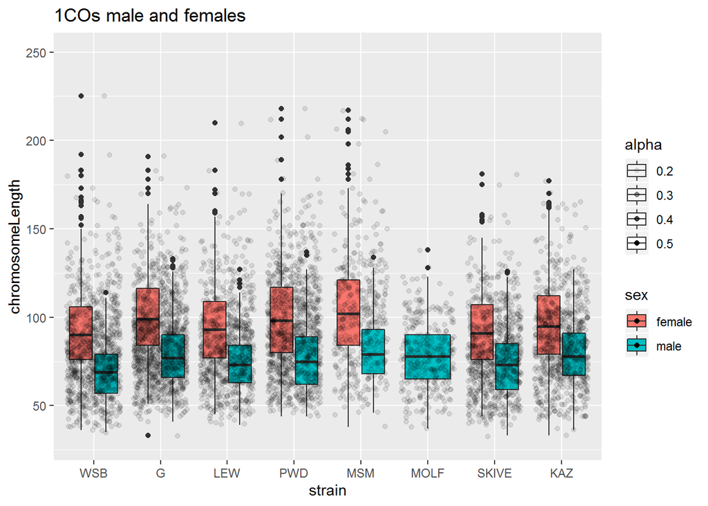

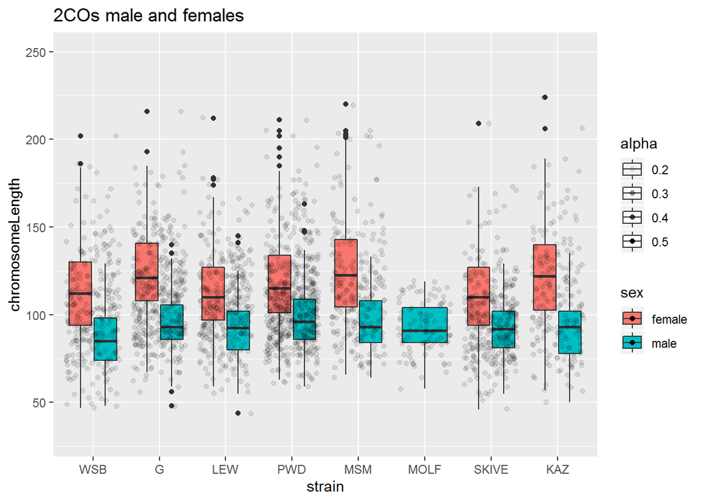

The above plots seperate bivalent classes. (Make a table of pvalues for t.tests of male to female SC lengths across strains.)

```
##                   Df  Sum Sq Mean Sq F value Pr(>F)
## hand.foci.count    1  929673  929673 1826.68 <2e-16 ***
## sex                1 1225522 1225522 2407.99 <2e-16 ***
## strain             7  147348   21050   41.36 <2e-16 ***
## Residuals       9553 4861911     509
## ---
## Signif. codes:  0 '***' 0.001 '**' 0.01 '*' 0.05 '.' 0.1 ' ' 1
```

By ANOVA analysis, everything has a significant effect.

# PERMUTATIONS Accounting for sample size differences

| Var1 | Freq |
| --- | --- |
| WSB female | 765 |
| WSB male | 592 |
| G female | 725 |
| G male | 1004 |
| LEW female | 714 |
| LEW male | 533 |
| PERC male | 0 |
| PWD female | 1030 |
| PWD male | 678 |
| MSM female | 549 |
| MSM male | 173 |
| MOLF female | 0 |
| MOLF male | 437 |
| SKIVE female | 488 |
| SKIVE male | 775 |
| KAZ female | 485 |
| KAZ male | 615 |
| CZECH female | 0 |
| CZECH male | 0 |
| AST male | 0 |
| TOM male | 0 |
| CAST female | 0 |
| CAST male | 0 |
| HMI female | 0 |
| HMI male | 0 |
| SPRET female | 0 |
| SPRET male | 0 |
| SPIC female | 0 |
| SPIC male | 0 |
| CAROLI female | 0 |
| CAROLI male | 0 |
| F1 | 0 |
| other | 0 |

Modeling SC lengths at the bivalent level is noisey. There are many levels and unequal sampling.

maybe I should compare the longest bivalent from a cell? or the shortest 4?

# Centromere supression

Anecdotally I would say that males have stronger centromere supression. I will also add a metric for telomere distance.

Verbalizing the inference from all the p values.

Using the same permuted / subsampled data frame – I’ll look at centromere and telomere distance

How would these distributions change normalized distances?

t.tests for centromere dis and telomere distance This result and the IFD could be the same mechanism.

## Higher recombining males have stronger interference

Do the same figure things for IFD

There might be too little 2CO observations for many dom chrm to get the IFDs

| Var1 | Freq |
| --- | --- |
| WSB female | 187 |
| WSB male | 107 |
| G female | 242 |
| G male | 183 |
| LEW female | 245 |
| LEW male | 106 |
| PERC male | 0 |
| PWD female | 285 |
| PWD male | 301 |
| MSM female | 159 |
| MSM male | 91 |
| MOLF female | 0 |
| MOLF male | 97 |
| SKIVE female | 113 |
| SKIVE male | 253 |
| KAZ female | 128 |
| KAZ male | 84 |
| CZECH female | 0 |
| CZECH male | 0 |
| AST male | 0 |
| TOM male | 0 |
| CAST female | 0 |
| CAST male | 0 |
| HMI female | 0 |
| HMI male | 0 |
| SPRET female | 0 |
| SPRET male | 0 |
| SPIC female | 0 |
| SPIC male | 0 |
| CAROLI female | 0 |
| CAROLI male | 0 |
| F1 | 0 |
| other | 0 |

## more variation across traits for females than males

## High recombining male mice have more total SC?

I think with total SC, this is true, but it doesn’t seem true for the single bivalent data. This could also be due to sampling issues.

# Interfocal comparisons

# Sis Co ten Metric

The metric Sis-co-ten measures the amount of sister cohesion connected to the other pole. Alternating IFDs. Assuming chromatid interference and no sister seperation, this should reflect the amount of sister cohesion that is pulled across the opposite pole.

need more MSM male curated measures!